# Assignment 11

Robert Wilbrand

2.2.2021

```r
library(tidyverse)
library(caret)
library(MASS)
theme_set(theme_bw())
knitr::opts_knit$set(root.dir = "C:/MSc GCG/QM/Data/data")
knitr::opts_chunk$set(message = FALSE, warning = FALSE)
options(scipen = 8)
```

## 1. Use the built-in iris dataset to build a linear discriminant analysis model that predicts Species from the four Sepal and Petal measurements. Note data(“iris”) loads the built-in dataset. Answer the following questions: 1) How many discriminant functions are estimated?

```r
data("iris")
iris <- as_tibble(iris)
summary(iris)
```

```
##   Sepal.Length    Sepal.Width     Petal.Length    Petal.Width
##  Min.   :4.300   Min.   :2.000   Min.   :1.000   Min.   :0.100
##  1st Qu.:5.100   1st Qu.:2.800   1st Qu.:1.600   1st Qu.:0.300
##  Median :5.800   Median :3.000   Median :4.350   Median :1.300
##  Mean   :5.843   Mean   :3.057   Mean   :3.758   Mean   :1.199
##  3rd Qu.:6.400   3rd Qu.:3.300   3rd Qu.:5.100   3rd Qu.:1.800
##  Max.   :7.900   Max.   :4.400   Max.   :6.900   Max.   :2.500
##        Species
##  setosa    :50
##  versicolor:50
##  virginica :50
##
##
##
```

```r
lda_iris <- lda(Species ~ ., iris)
lda_iris
```

```
## Call:
## lda(Species ~ ., data = iris)
##
## Prior probabilities of groups:
##     setosa versicolor  virginica
##  0.3333333  0.3333333  0.3333333
##
## Group means:
##            Sepal.Length Sepal.Width Petal.Length Petal.Width
## setosa            5.006       3.428        1.462       0.246
## versicolor        5.936       2.770        4.260       1.326
## virginica         6.588       2.974        5.552       2.026
##
## Coefficients of linear discriminants:
##                     LD1         LD2
## Sepal.Length  0.8293776  0.02410215
## Sepal.Width   1.5344731  2.16452123
## Petal.Length -2.2012117 -0.93192121
## Petal.Width  -2.8104603  2.83918785
##
## Proportion of trace:
##    LD1    LD2
## 0.9912 0.0088
```

```r
iris_pred <- predict(lda_iris)
table(iris_pred$class, iris$Species)
```

```
##
##              setosa versicolor virginica
##   setosa         50          0         0
##   versicolor      0         48         1
##   virginica       0          2        49
```

Two discriminant functions are estimated from the data (one fewer than the number of categories).

## 2. How many discriminant functions might be needed to distinguish the three Species? Show and explain why.

```r
lda_iris$svd^2 / sum(lda_iris$svd^2)
```

```
## [1] 0.991212605 0.008787395
```

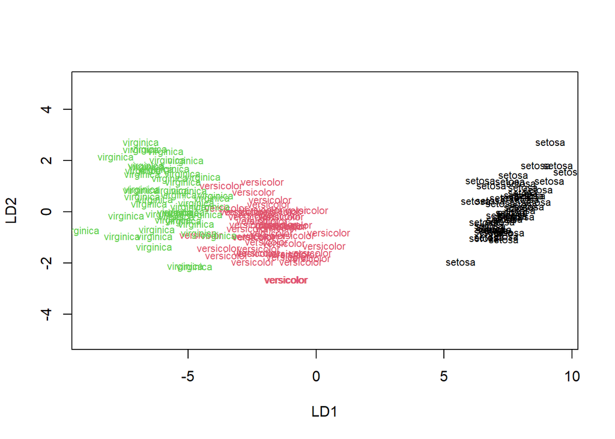

```r
plot(lda_iris, col = as.numeric(iris$Species))
```

LD1 explains over 99% of the variance in the data, so LD2 is not necessary to distinguish between species. The plot illustrates this nicely as well.

## 3. Which of the 4 variables are most important for distinguishing species? Show and explain why.

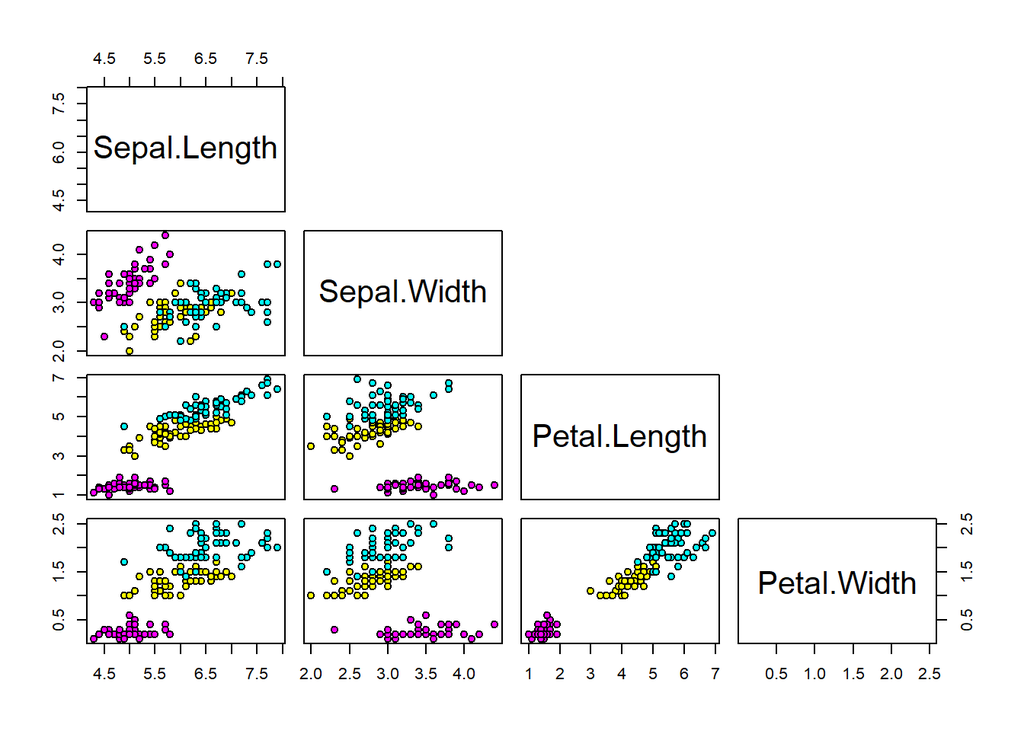

```r
pairs(iris[,1:4], upper.panel=NULL, pch=21,
      bg=c("magenta","yellow","cyan")[as.factor(iris$Species)])
```

Petal width has the largest contribution to both discriminant functions (in terms of absolute value) and is thus most important for telling species apart. This can also be seen visually in the graph.

## 4. Use leave-one-out crossvalidation to predict species with linear discriminant function analysis. Show the resulting confusion matrix and estimate the overall classification accuracy? Show and describe your results.

```r
lda_iris2 <- lda(Species ~ ., iris, CV=T)
confusionMatrix(lda_iris2$class, iris$Species)
```

```
## Confusion Matrix and Statistics
##
##             Reference
## Prediction   setosa versicolor virginica
##   setosa         50          0         0
##   versicolor      0         48         1
##   virginica       0          2        49
##
## Overall Statistics
##
##                Accuracy : 0.98
##                  95% CI : (0.9427, 0.9959)
##     No Information Rate : 0.3333
##     P-Value [Acc > NIR] : < 2.2e-16
##
##                   Kappa : 0.97
##
##  Mcnemar's Test P-Value : NA
##
## Statistics by Class:
##
##                      Class: setosa Class: versicolor Class: virginica
## Sensitivity                 1.0000            0.9600           0.9800
## Specificity                 1.0000            0.9900           0.9800
## Pos Pred Value              1.0000            0.9796           0.9608
## Neg Pred Value              1.0000            0.9802           0.9899
## Prevalence                  0.3333            0.3333           0.3333
## Detection Rate              0.3333            0.3200           0.3267
## Detection Prevalence        0.3333            0.3267           0.3400
## Balanced Accuracy           1.0000            0.9750           0.9800
```

The confusion matrix doesn’t change when introducing leave-one-out cross-validation. Overall accuracy is ~98%. Setosa can be identified perfectly, but there are misclassifications between the two other species.